# Money, prices and the exchange rate

Session 2

Luis F. Gómez L.

luis.gomezl@unimilitar.edu.co

Distance Learning Faculty

10 February, 2026

# Please Read Me

- Check the message **Welcome greeting** published in Announcements forum.
- Dear student please edit your profile uploading a photo where your face is clearly visible.
- If you want to participate, please fill out the following survey: **Primer corte 30% > Learning Activities > Tu opinión sobre la economía colombiana**
- This presentation is based on (Cardenas, 2020, Chapter 7)
- **Purpose**
  - Analyze the money market and introduce the concepts of inflation, nominal exchange rate and interest rate

# Monetary policy intervention rate

- In the link [**https://suameca.banrep.gov.co/estadisticas-economicas/informacionSerie/59/tasas_interes_politica_monetaria**](https://suameca.banrep.gov.co/estadisticas-economicas/informacionSerie/59/tasas_interes_politica_monetaria) > Información sobre la(s) serie(s) > Descripción on **2026-02-08** it was pointed out that:
  - *“La tasa de intervención de política monetaria es la tasa de interés mínima que el Banco de la República cobra a las entidades financieras por los préstamos que les hace mediante las operaciones de mercado abierto (OMA) que se otorgan en las subastas de expansión monetaria a un día hábil (plazo overnight).”*
  - *“Esta tasa es el principal mecanismo de intervención de política monetaria usado por el Banco de la República para afectar la cantidad de dinero que circula en la economía.”*
  - *“La Junta Directiva del Banco de la República define la tasa de intervención de política monetaria y sus decisiones tienen vigencia a partir del día hábil siguiente a la sesión de la Junta.”*
- Also the *“tasa de intervención de política monetaria”* on **2026-02-08** was **10.25%**

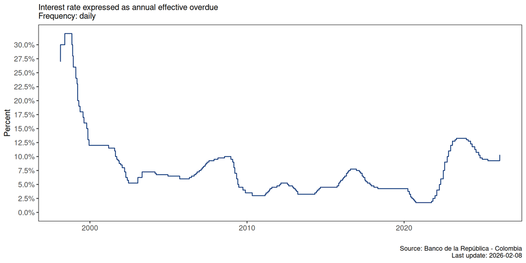

Figure 1: Monetary policy intervention rate of the Bank of the Republic (Colombia)

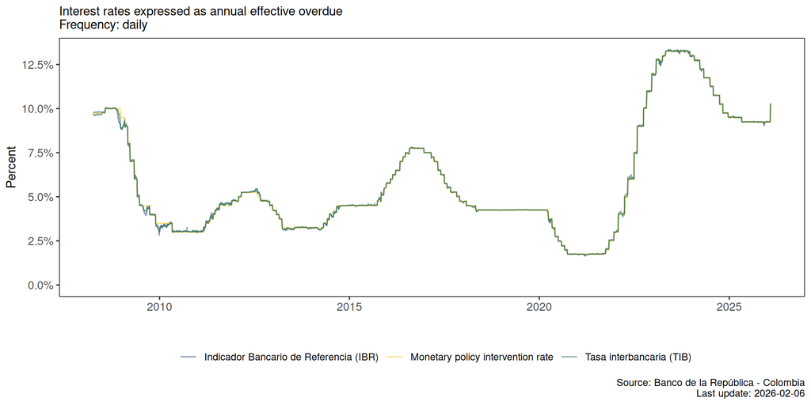

Figure 2: Monetary policy intervention rate, TIB and IBR

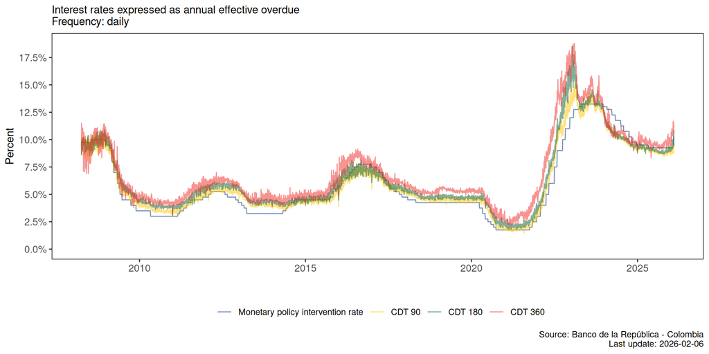

Figure 3: Monetary policy intervention rate and CDT interest rates

# Monetary policy transmission channels

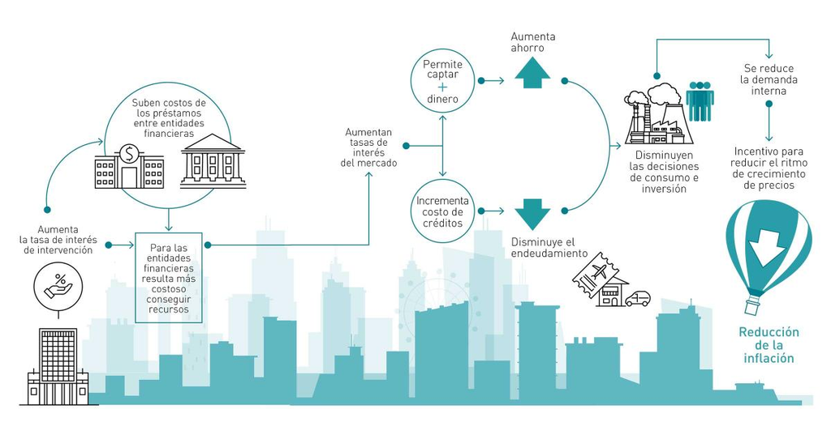

Figure 4: **Interest rate and credit** (Banrep, 2022, fig. Canal de tasa de interés y de crédito: ejemplo gráfico)

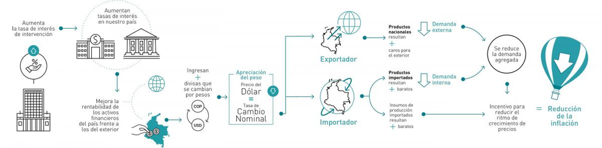

Figure 5: **Exchange rate** (Banrep, 2022, fig. Canal de la casa de cambio: ejemplo gráfico)

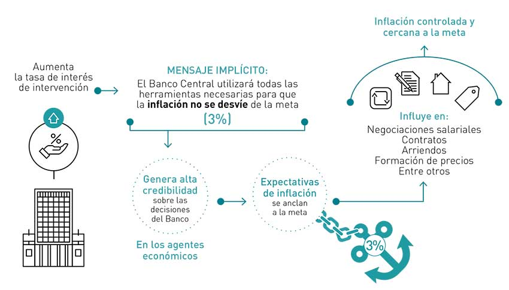

Figure 6: **Expectations** (Banrep, 2022, fig. Canal de las expectativas: ejemplo gráfico)

# Why a low and stable inflation?

- When inflation is high or volatile, it becomes difficult for businesses and individuals to plan for the future.
  - Low and stable inflation allows for more accurate long-term planning.
- High or volatile inflation is an obstacle for businesses to make sound investment decisions.
  - When inflation is high or volatile some resources are allocated to mitigate the effects of inflation generating an inneficient use of productive resources.
- High or volatile inflation can lead to arbitrary redistributions of resources, often harming those with fixed incomes or limited financial resources
  - Low and stable inflation helps to limit those unexpected redistributions

# Why not a desire level of inflation equal to zero?

- Zero inflation increases the risk of deflation, which is a sustained decrease in the general price level.
  - When prices are expected to fall, consumers and businesses tend to delay purchases and investments, hoping to buy things cheaper in the future. This leads to a decrease in demand, which further drives down prices.
- Inflation statistics can overstate actual inflation due to difficulties in accurately measuring quality improvements in products.
  - If this is the case and the desire level of inflation is zero you may be targeting a negative inflation rate.

# Why central bank independence is important?

- What is central bank independence?
  - *“An independent central bank is one that can carry out monetary policy without political interference.”* (CEA, 2024)
  - *“An independent central bank is one that can carry out monetary policy insulated from pressures arising from other parts of government or elsewhere.”* (D. Kugler, 2024)
- Why independence is important for a central bank?
  - Independence is a critical component for a central bank to control inflation.
    - Central bank’s commitment to lower inflation needs credibility to anchor the expectations of the economic agents. Independence prevent that credibility can be undermine by political influence (CEA, 2024).
    - Central bank targets, like mantaining a low and stable level of inflation, operate over a considerably longer time frame compare to politically-motivated policies. A non-independent central bank can face political pressure to change its behavior where in that situation can not achieve its targets (CEA, 2024).
- According to (D. Kugler, 2024) and explored in the economic literature a central bank is a possible solution to this problems where the governments delegate the monetary policy to an independent entity.
- The best analogy that represents this situation and pointed out by (D. Kugler, 2024) is Ulysses and the Sirens vs short-term desires and longer-term goals.

[figure not shown]

Figure 7: Ulysses and the Sirens (1909) by Herbert James Draper

# Acknowledgments

- To my family that supports me
- To the taxpayers of Colombia and the [**UMNG students**](https://www.umng.edu.co/estudiante) who pay my salary
- To the [**Business Science**](https://www.business-science.io/) and [**R4DS Online Learning**](https://www.rfordatasci.com/) communities where I learn [**R**](https://www.r-project.org/about.html) and [**$\pi$-thon**](https://www.python.org/about/)
- To the [**R Core Team**](https://www.r-project.org/contributors.html), the creators of [**RStudio IDE**](https://posit.co/download/rstudio-desktop/), [**Positron**](https://positron.posit.co/), [**Quarto**](https://quarto.org/) and the authors and maintainers of the packages [**tidyverse**](https://CRAN.R-project.org/package=tidyverse), [**scales**](https://CRAN.R-project.org/package=scales) and [**tinytex**](https://CRAN.R-project.org/package=tinytex) for allowing me to access these tools without paying for a license

# References

Banrep. (2022). Econo-cimientos: Canales de transmisión de la política monetaria. In *Banco de la República (banco central de Colombia)*. https://www.banrep.gov.co/es/banrep-educa/econo-cimientos/canales-transmision-politica-monetaria

Cardenas, M. (2020). *Introducción a la Economía Colombiana* (4th ed.). Alfaomega.

CEA. (2024). The Importance of Central Bank Independence CEA. In *The White House*. https://bidenwhitehouse.archives.gov/cea/written-materials/2024/05/22/the-importance-of-central-bank-independence/

D. Kugler, A. (2024). Speech by Governor Kugler on central bank independence and the conduct of monetary policy. In *Board of Governors of the Federal Reserve System*. https://www.federalreserve.gov/newsevents/speech/kugler20241114a.htm